# Discovery and Data Prep

## Deliverable 1

# Introduction

My Dataset is about League of Legends Professional matches and various stats about each game.

# The Data

I’ve used a subset of the data that I was given for this first deliverable.

# Source

I retrieved my Data from kaggle and used it to created some more variables based off of their data.

# In Depth of Variables

region - the Region that the match was played  
year  
winner  
blueTeam  
redTeam  
gameTime  
*The rest of the variables can be described as  
staring with r -> red team  
starting with b-> blue team  
ending with C meaning they are a Champion  
not ending with C meaning the Player  
T -> Top  
J -> Jungle  
M -> Middle  
AD -> Marksman  
S -> Support  
the last four variables are the lists of champs/players that I used to help more easily create my data.

## Visuals for Deliverable 1

# Win percentage of each player

These players all have more than 100 Games played

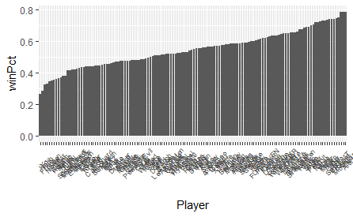

```r
Players100 <- filter(Players, games > 100)
Players100$Player <- factor(Players100$Player, levels = Players100$Player[order(Players100$winPct)])
ggplot(Players100, aes(x = Player, y = winPct)) + theme(axis.text.x=element_text(angle=45, size = rel(0.75), margin = margin(0.5, unit = "cm"))) + geom_col()
```

The graph is slightly hard to see so here are the top win percentages and the lowest win percentages out of people that have over 100 games

```r
head(Players100[order(Players100$winPct),])
```

|  | Player | wins | games | winPct |
| --- | --- | --- | --- | --- |
| 53 | Yo | 30 | 113 | 0.2654867 |
| 90 | Keith | 29 | 101 | 0.2871287 |
| 104 | Fury | 40 | 123 | 0.3252033 |
| 62 | Froggen | 46 | 139 | 0.3309353 |
| 9 | Gate | 44 | 127 | 0.3464567 |
| 98 | Nuclear | 39 | 112 | 0.3482143 |

```r
tail(Players100[order(Players100$winPct),])
```

|  | Player | wins | games | winPct |
| --- | --- | --- | --- | --- |
| 132 | SwordArT | 80 | 108 | 0.7407407 |
| 117 | Biofrost | 75 | 101 | 0.7425743 |
| 44 | Bengi | 104 | 139 | 0.7482014 |
| 52 | Mountain | 107 | 137 | 0.7810219 |
| 25 | Ziv | 125 | 160 | 0.7812500 |
| 49 | Albis | 124 | 158 | 0.7848101 |

# Number of times each champion was picked

These are the counts of how many times each champion was picked in competitive matches

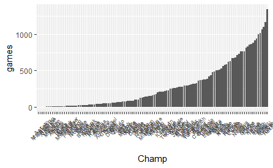

Since the graph is a little cluttered at the moment since every champion is added, here is the least picked and most picked champs

```r
head(Champs[order(Champs$games),])
```

|  | Champ | wins | games | winPct |
| --- | --- | --- | --- | --- |
| 76 | Aatrox | 1 | 1 | 1.0000000 |
| 78 | MonkeyKing | 1 | 1 | 1.0000000 |
| 69 | FiddleSticks | 1 | 2 | 0.5000000 |
| 108 | Nasus | 0 | 2 | 0.0000000 |
| 201 | XinZhao | 1 | 2 | 0.5000000 |
| 61 | Akali | 1 | 3 | 0.3333333 |

```r
tail(Champs[order(Champs$games),])
```

|  | Champ | wins | games | winPct |
| --- | --- | --- | --- | --- |
| 66 | Elise | 497 | 999 | 0.4974975 |
| 126 | Alistar | 511 | 1019 | 0.5014720 |
| 8 | Maokai | 571 | 1069 | 0.5341441 |
| 17 | Gragas | 576 | 1102 | 0.5226860 |
| 109 | Sivir | 626 | 1171 | 0.5345858 |
| 55 | RekSai | 654 | 1345 | 0.4862454 |

## Future Questions

Some things I want to look into is how champion win rates and player win rates have changed over time

Right now I only have them clumped into the same category, I will need to split up the statistics by the year the game was played.

Another thing that I want to look at is the average game time with respect to the gold differences/towers/dragons/barons and kills.

One thing that I can’t look into is what updates were released about the game. Some updates have been known to extend/reduce game times.

Individual champions have also had changes to them that will affect how good they are resulting in either a higher or lower win rate.